# RMarkdown Practice

I recommend starting all R Markdown documents with a setup chunk that includes:  
* All libraries you need to load  
* Any knitr options (knitr::opts_chunk) you’d like to use  
* Load any RData, csv, or other files used in analysis  
* Colors to be used throughout the analysis

I find that this is helpful for keeping your code and overall document clean and easy to read.

## Some thoughts about `setwd()`

I generally recommend against using `setwd()` in any code. Here’s why:  
* If you use RProjects, you can open your RProject, and it sets your working directory for you (to the folder the RProject is located in). So, no need to bother.  
* This is also **extremely helpful** for collaborations, because collaborators don’t have to change your `setwd()` code to work on their computer. It just automatically works when they open the RProject.

`include = FALSE` will run the code, but will not include the code or the results in the knitted document.

`cache = TRUE` will cache the results of that particular chunk, and the next time you knit, will only re-run that chunk if the code within that chunk has changed. This is particularly useful for computationally heavy models, etc. that you might not want to wait for every time you knit.

## Code Readability

For information about how to format an RMarkdown document, see https://rmarkdown.rstudio.com/authoring_basics.html

As in R scripts, you can use a newline (enter) after a comma in your code for readability

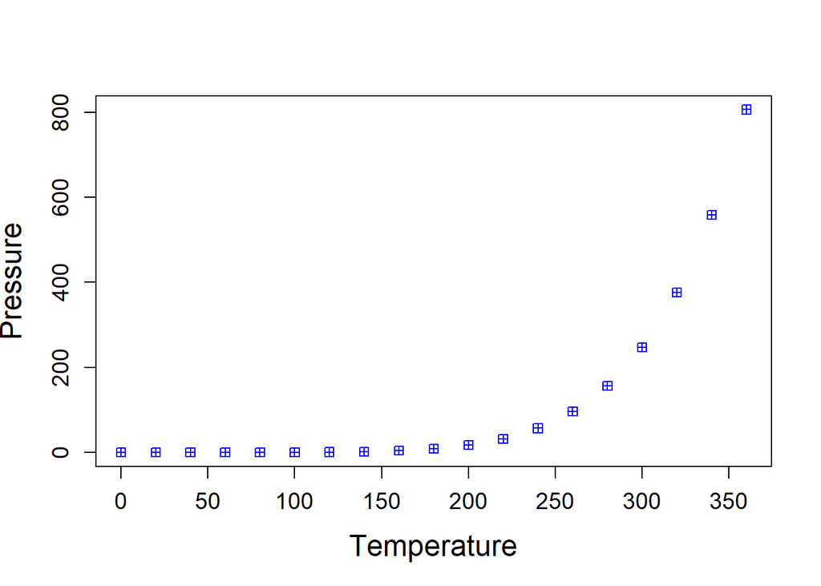

```r
plot(pressure, pch = 12, col = "blue",
     cex.axis = 1.2, cex.lab = 1.5, # You can add comments here too
     ylab = "Pressure", xlab = "Temperature")
```